# 非线性模型（第二版）

潘璐璐（第一稿），朱谦（第二稿），汤磊（第三稿）

*学习资源来自于Gareth James等的《统计学习导论——基于R应用》，*  
*提供的代码可见于http://www-bcf.usc.edu/~gareth/ISL/Chapter%207%20Lab.txt*

非线性模型内容：

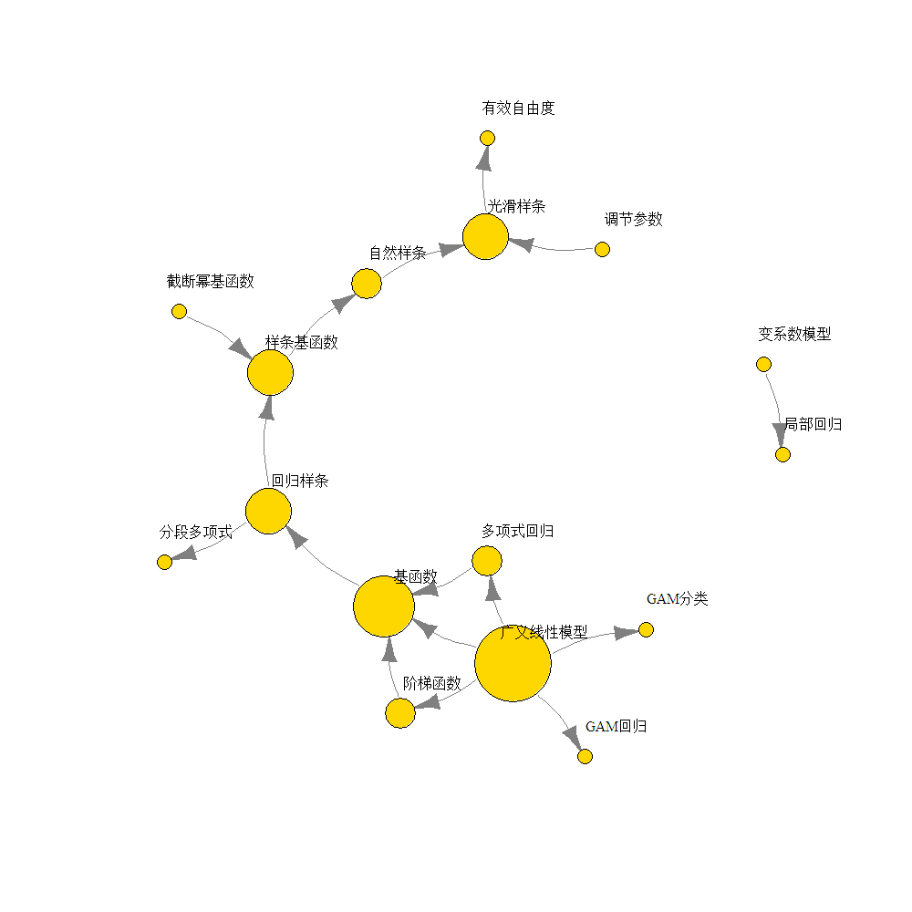

线性模型的关键原则是变量之间存在线性关系，但这只是一个漂亮的简化假设，在实际中，变量之间的关系往往是非线性的，本章的模型是在线性模型上的简单推广，力图在保持模型良好前提下，放松线性假设。

# 1 多项式回归

**回顾**第三章回归

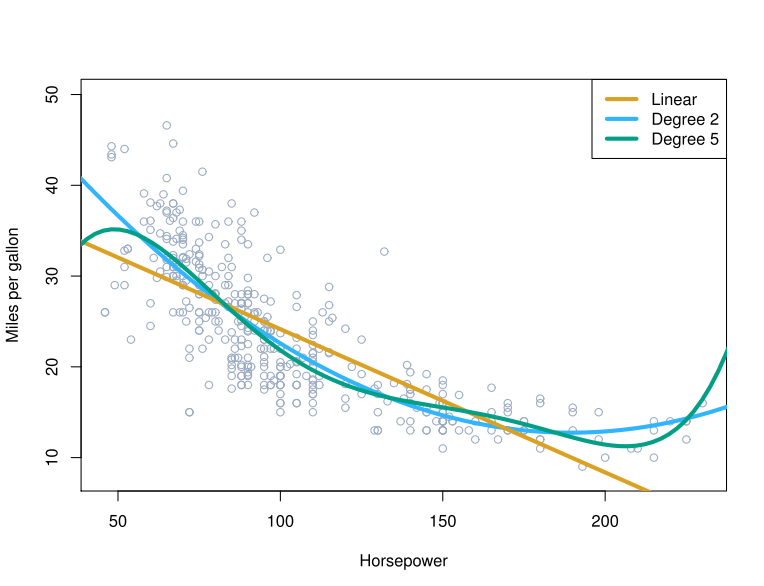

在3.3.2节中，线性模型的拓展的讨论中提及过多项式回归，在汽车油耗-马力关系图中，数据呈现出一种曲线关系，线性回归拟合的效果并不是太好。

**对线性模型的拓展思路**是以预测变量的幂作为新的预测变量以替代原始变量, 将标准线性模型

$$y_i=\beta_0+\beta_1x_i+\varepsilon_i$$
转化为一个多项式函数
$$y_i=\beta_0+\beta_1x_i+\beta_2x_i^2+...+\beta_dx_i^d+\varepsilon_i$$
通过添加多项式（即$x^d$）来提高线性回归的预测精度，这种方法称为**多项式回归**。 因为从本质上来说，还是对于$x_i,x_i^2,x_i^3,...,x_i^d$的线性模型，所以用OLS方法就可以计算多项式函数的系数。

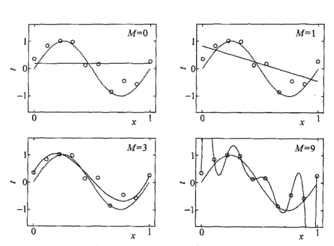

**多项式回归的实现**：下图的数据是包含在ISLR程序包的Wage数据集中，左上角散点图包含了居住在美国亚特兰大中部地区男性的收入（wage，单位：千美元）和人口信息（age，年龄）；图中蓝色实线是使用最小二乘法拟合的四阶多项式回归的结果
$$wage=-184.15+21.245age-0.564age^2+0.0068age^3-0.00003age^4$$
虚线表示95%置信区间。

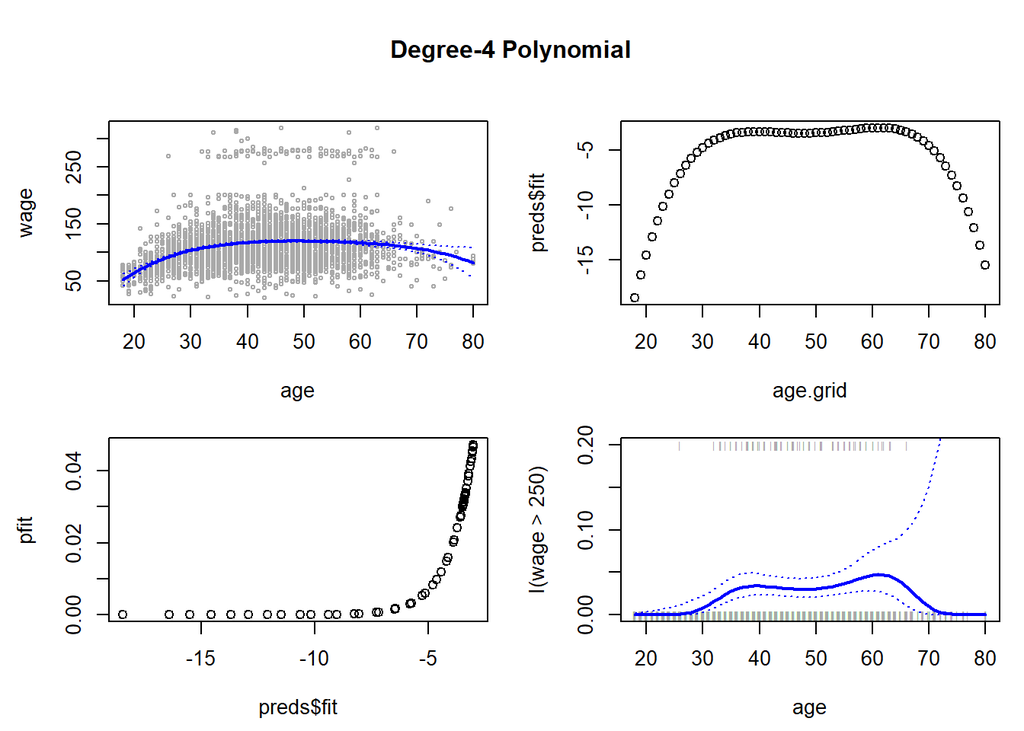

下面两图：左图是把wage当做二元变量，以250为分界线，做二分类问题，这样就能以逻辑斯谛回归来预测：
$$Pr(y_i>250|x_i)=\frac{e^{\beta_0+\beta_1x_i+\beta_2x_i^2+\beta_3x_i^3+\beta_4x_i^4}}{1+e^{\beta_0+\beta_1x_i+\beta_2x_i^2+\beta_3x_i^3+\beta_4x_i^4}}$$
逻辑斯谛回归的样本数（n=79）较少，估计系数方差较大，置信区间较宽。

右图是针对二元变量wage>250的逻辑斯谛回归模型建模结果，通常采用4阶多项式，蓝色实线表示wage>250的后验概率，虚线则是估计的95%置信区间。左下角和右上角的两幅图片是逻辑斯谛回归的中间过程，将I(wage>250)这一0-1形式的因变量转化以后，用四次多项式拟合其结果，得到右上角图片，转化的形式见于左下角图像，最后将拟合结果转化回概率的形式，得到右图。

# 2 阶梯函数

如果不希望得到全局的模型，可以使用阶梯函数拟合，是一种提供连续变量离散化成有序分类变量的方法。 基本思想：将某个预测变量的取值空间切割成K个不同区域，生成一个新的定性变量，分段拟合一个常量函数  
$C_0(X)=I(X<c_1)$  
$C_1(X)=I(c_1\leq X<c_2)$  
$C_2(X)=I(c_2\leq X<c_3)$  
$.....$  
$C_{K-1}(X)=I(c_{K-1}\leq X<c_K)$  
$C_K(X)=I(c_K\leq X)$

其中，I(.)为示性函数（通常叫指示函数），当条件成立时返回1，否则返回0，由于X只能落在K+1个区间中的某一个，于是对任意X的取值$C_0(X)+C_1(X)+...+C_K(X)=1$，以$C_0(X)、C_1(X),.....,C_K(X)$为预测变量用最小二乘法来拟合线性模型：
$$y_i=\beta_0+\beta_1C_1(x_i)+\beta_2C_2(x_i)+...+\beta_KC_K(x_i)+\varepsilon_i$$
当$X<c_1$时，式中每个预测变量都为0，因此$\beta_0$成为$X<c_1$时的Y的平均值；
当$c_j<X<c_j+1$时，预测值为$\beta_0+\beta_j$，$\beta_j$即指当X 由$X<c_1$增加到$c_j<X<c_j+1$时，响应变量的平均增量

> 同上，调整逻辑斯蒂回归图

用和多项式回归同样的方法，使用阶梯函数反映年龄和收入的关系
$$Pr(y_i>250|x_i)=\frac{e^{\beta_0+\beta_1C_1(x_i)+\beta_2C_2(x_i)+...+\beta_KC_K(x_i)}}{1+e^{\beta_0+\beta_1C_1(x_i)+\beta_2C_2(x_i)+...+\beta_KC_K(x_i)}}$$

```
##
## (17.9,33.5]   (33.5,49]   (49,64.5] (64.5,80.1]
##         750        1399         779          72
```

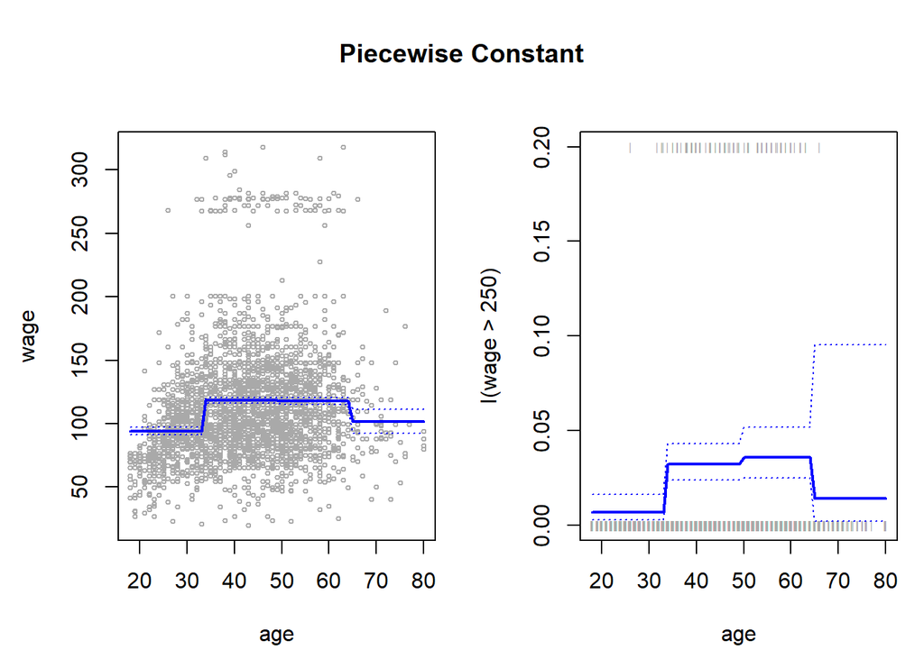

如果预测变量本书不具有明显的分割点，那么分段给出一个常数就不是特别恰当，例如左边这幅图中，第一阶梯中收入增长的趋势就没有表现出来。

# 3 基函数

多项式和阶梯函数回归模型实际上是特殊的基函数方法，基本原理是不直接对X进行建模，而是对变量X的函数或变换$b_1(X),b_2(X),...,b_k(X)$进行建模
$$y_i=\beta_0+\beta_1b_1(x_i)+\beta_2b_2(x_i)+...+\beta_Kb_K(x_i)+\varepsilon_i$$
从而来代替线性模型，
对于多项式回归来说，基函数就是$b_j(x_i)=x_i^j$，
而对于阶梯函数来说，基函数就是$b_j(x_i)=I(c_j\leq x_i<c_{j+1})$。

# 4 回归样条

回归样条也是一种基函数，可以看做是前面两种方法的推广。

**基本方法：**首先将X的取值范围切割成K个区域，在每个区域分别独立拟合一个多项式函数。回归样条的多项式一般有一些限制以保证在区域边界或称为结点的位置，这些多项式得到光滑的链接。只要X被切割成尽可能多的领域，这个方法就能产生非常光滑的拟合效果。

## 4.1 分段多项式

可以理解为将x的取值范围分为多段，在每一段分别进行低阶的多项式回归，在不同区域内$\beta_0,\beta_1,\beta_2$等，均互不相同。而这些系数发生变化的临界点称为**结点**（knot）。

例如，下面的公式即表示只有一个结点c的分段三次多项式，每一个分段都可以各自拟合其多项式。
$$y=\left\{
\begin{array}{lr}
\beta_{01}+\beta_{11}x_i+\beta_{21}x_i^2+\beta_{31}x_i^3+\varepsilon_i, & x_i<c &;\\
\beta_{02}+\beta_{12}x_i+\beta_{22}x_i^2+\beta_{32}x_i^3+\varepsilon_i, & x_i\geq c & .
\end{array}
\right.$$
事实上，阶梯函数可以看做阶数为0的分段多项式。

## 4.2 约束条件与样条

将前面的年龄和收入数据以age=50为结点，用分段三次多项式进行回归分析。

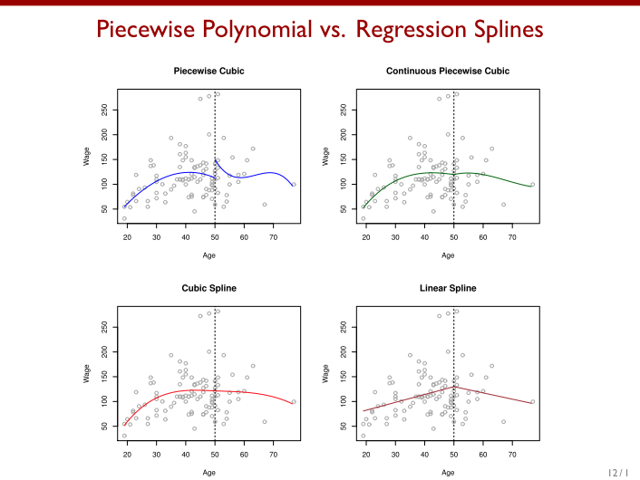

左上角的图片看上去比较光滑，但是在结点上不连续，为了确保拟合曲线的连续性，需要添加约束条件。  
右上角约束条件：连续  
左下角（三次样条）约束条件：连续，且一阶导数、二阶导数存在（光滑）  
右下角（线性样条）约束条件：结点age=50处连续

从上图可知，采用更多的约束条件则可以得到更光滑的分段多项式。 这是因为，每个对分段三次多项式施加的约束都有效的释放了一个自由度，减少了模型的复杂程度。 例如，对于左上图中原本自由度为8的分段三次多项式
$$f(x)=\left\{
\begin{array}{lr}
\beta_{1}+\beta_{2}x+\beta_{3}x^2+\beta_{4}x^3+\varepsilon, & x<\xi &;\\
\beta_{5}+\beta_{6}x+\beta_{7}x^2+\beta_{8}x^3+\varepsilon, & x\geq \xi & .
\end{array}
\right.$$
三次样条的约束条件$f(ξ−)=f(ξ+),f'(ξ−)=f'(ξ+),f''(ξ−)=f''(ξ+)$意味着
$$\left\{
\begin{array}{lr}
β_1+β_2ξ+β_3ξ^2+β_4ξ^3=β_5+β_6ξ+β_7ξ^2+β_8ξ^3 \\
β_2+2β_3ξ+3β_4ξ^2=β_6+2β_7ξ+3β_8ξ^2 \\
2β_3+6β_4ξ=2β_7+6β_8ξ
\end{array}
\right.$$

> 在统计学中，自由度(degree of freedom, df) 指的是计算某一统计量时，取值不受限制的变量个数。通常df=n-k。其中n为样本数量，k为被限制的条件数或变量个数，或计算某一统计量时用到其它独立统计量的个数。此处要求的统计量为系数向量β的拟合值，每增加一个约束，则β减少一自由度。

在这种情形下，三个约束，减少了三个需要估计的参数，意即，单结点的三次样条存在5个自由度。在一般情况下，与K个结点一同使用的三次样条会产生4+K个自由度。 （自由度+=1<-结点+=1）

### 4.2.1 样条

**什么是样条** 样条的概念源自制图技术，即让富有弹性的细长木条（称为样条）通过一组点，然后得到光滑的曲线。这些点可以使用钉子或者大头针标出，用样条绕过这些点，就得到了样条曲线。  
样条是一个由多项式构造的分段函数，并且在分段节点处要具有高度平滑的特性，即在分段结点处连续且有连续的导数。

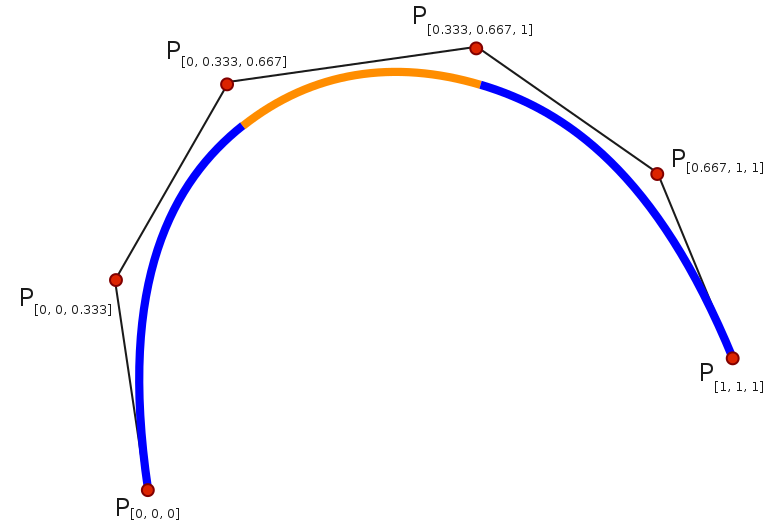

《统计学习导论》中“阶”和“次”的概念与百度百科定义的不一致，可能存在问题，采用百度百科的定义：

**曲线次数**：样条曲线的次数是由基函数决定的。某一段样条曲线，由控制多边形的相邻连续的几段折线段决定，就是几次样条，最常用的就是二次和三次样条。*二次样条*的某一曲线段只与相应的两段折线段，三个控制多边形顶点有关，改变其中一个顶点，将影响三段样条曲线段，样条函数S(x)需要满足以下条件：S(x)在每个区间上是一个二次多项式，每个结点上具有一阶连续导数；*三次样条*，每一曲线段由相应的三段折线段、四个结点决定，具体的控制要求：各个结点处函数值、一阶导数值、二阶导数值连续。

**曲线阶数**：样条阶数=样条次数+1

《统计学习导论》：**d阶样条**：分段d阶多项式；每个结点的d-1阶导数都是连续的。

例，线性样条可以通过下方式得到：在每个区域内拟合一条直线，同时要求在各结点处满足连续性。

## 4.3 样条基函数

本节主要讲的内容是d阶分段多项式的拟合方法 在回归样条中引入基函数的概念， 例如，对于有K个结点的三次样条函数，可以选择合适的$b_1,b_2,...,b_{K+3}$，作为基函数，形成如下表达式：
$$y_i=\beta_0+\beta_1b_1(x_i)+\beta_2b_2(x_i)+...+\beta_{K+3}b_{K+3}(x_i)+\varepsilon_i$$

可以选择不同的基函数来得到等价的三次样条。 最直接的方法就是之前用到的三次多项式$x$,$x^2$,$x^3$，但仅仅估计截距项和这三项的系数是不足以拟合出一条光滑的曲线的，在这种方法里，需要对每个节点$\xi$加一个**截断幂基函数**：
$$h(x,\xi)=(x-\xi)^3_+=\left\{
\begin{array}{lr}
(x-\xi)^3 & x>\xi\\
0 & 否则
\end{array}
\right.$$
原来的每一个分段三次多项式，都可以添加上$\beta_4h(x,\xi)$。 由于有这个截断幂基函数的存在，新的函数能够保证在$\xi$点，本身、一阶导数、二阶导数连续，但三阶导数不连续。此时，只需要根据函数
$$Y=\beta_0+\beta_1X+\beta_2X^2+\beta_3X^3+\beta_4h(X,\xi_1)+\beta_5h(X,\xi_2)+...+\beta_{K+3}h(X,\xi_{K})+\varepsilon$$
用最小二乘法进行回归，就可以估计这个三次样条的K+4个系数。

**自然样条**：是在边界上附加了线性约束的回归样条，这个约束条件可以使自然样条的估计在边界区域更稳定。 （边界区域是定义域比最小的结点更小，比最大的结点更大的部分）

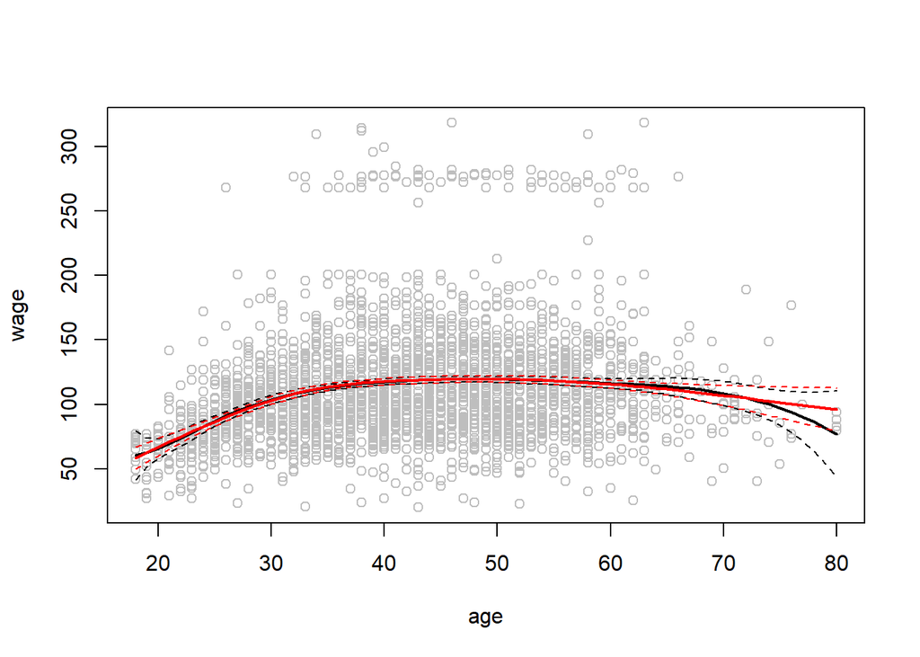

## 4.4 确定结点的个数和位置

在前面的讲解中，结点age=50或者结点age=(25,40,60)都是人为给定的，那么在拟合样条的时候能不能够找到一个合适的结点向量，得到最好的拟合结果呢？ 实践证明有两种方法： 1.在变化相对稳定的区间设置尽量少的结点，在变化相对快速的地方设置尽量多的结点，令结点在数据上呈现均匀分布是一种比较有效的结点选择方式。 2.设置自由度，然后依靠软件自动在数据的均匀分位数点上设置相应个数的结点，得到最优的结点位置。

需要注意的是自然样条的自由度计算方式普通样条的自由度计算方式不一致。

普通三次样条的自由度：K+4（K为结点数）

三次自然样条的自由度：K+4-2(-1)

下图中的样条设置了三个结点，如果是普通的三次样条，它的自由度应该是7，但通过代码可以看到，我们用的是4个自由度的自然样条，这是因为自然样条在定义域的两侧都增加了约束，通过下面这样的式子，参数的自由度相应的减少了两个，在R中，我们不把截距项的自由度计算在内，因此就参数df的值就是4。

$$\left\{
\begin{array}{lr}
Y'(\xi_0)=\beta_1+2\beta_2\xi_0+3\beta_3\xi_0^2=C_1\\
Y'(\xi_{K+1})=\beta_1+2\beta_2\xi_{K+1}+3\beta_3\xi_{K+1}^2+\beta_4h'(\xi_{K+1},\xi_1)+\beta_5h'(\xi_{K+1},\xi_2)+...+\beta_{K+3}h'(\xi_{K+1},\xi_{K})=C_2
\end{array}
\right.$$

```
fit=lm(wage~ns(age,df=4),data=Wage)
```

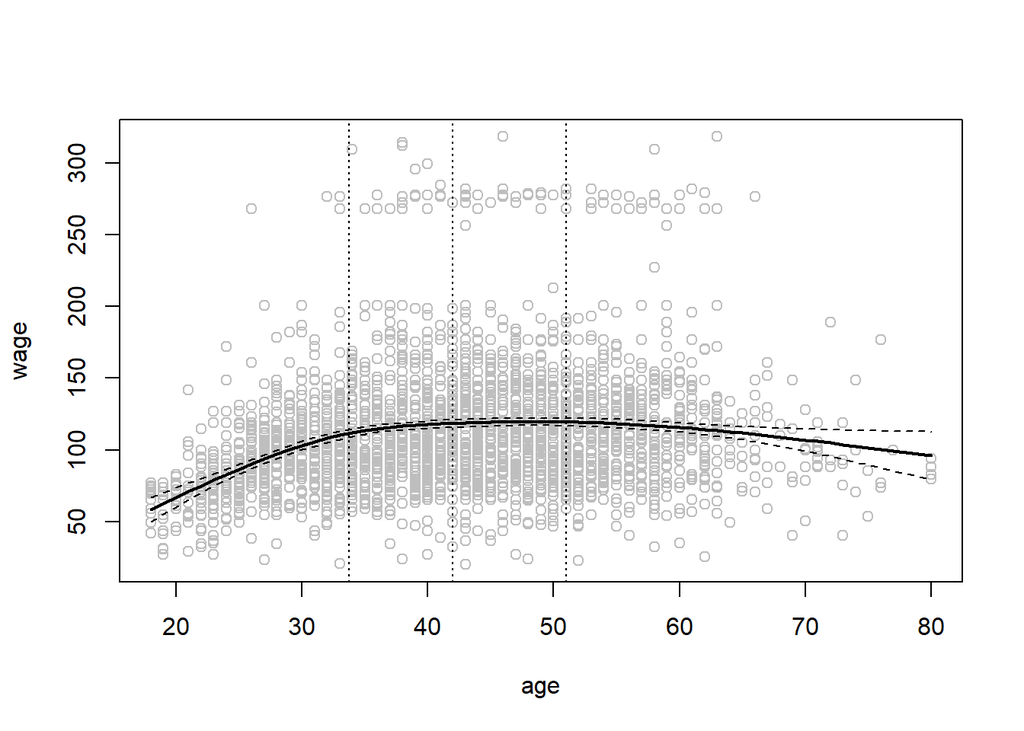

样条函数的自由度选定的方法：

- 一种是尝试多个不同的节点个数，然后从中选择拟合的“形状最理想”的曲线，
- 另一种较为客观的方法是使用交叉验证法。使用交叉验证时，首先移除一部分数据，然后用剩余的数据来拟合，接着用拟合得到的样条函数来对溢出的那一部分进行预测，这样不断重复多次知道所有数据都被移除过一次，最后计算整体的交叉验证RSS。整个步骤对不同的结点数目K不断重复，选择RSS最小的样条函数对应的K。

从下图来看，对于自然样条来说，自由度为3时就足够了。

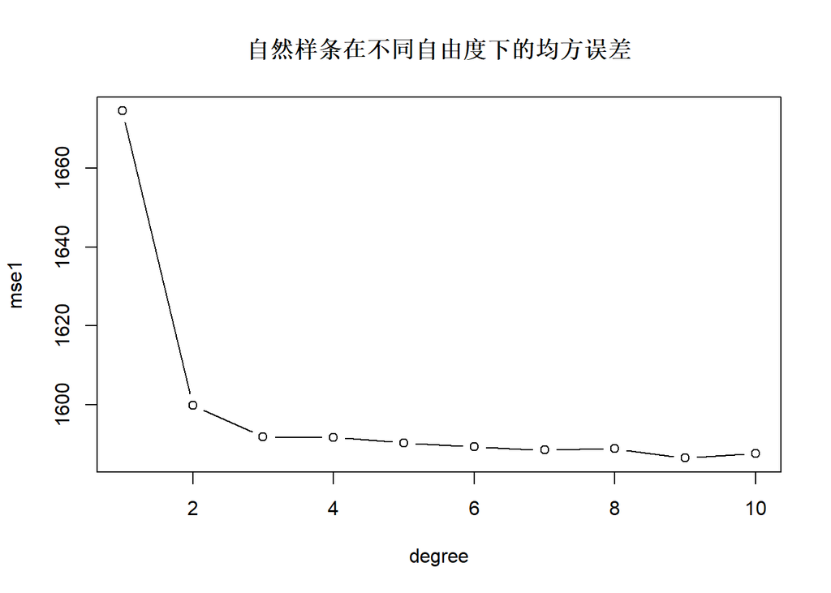

## 4.5 与多项式回归对比

同样是15个自由度的回归，回归样条的结果要明显的优于15次多项式的回归，尤其是对于自然三次样条而言，在边界上会有更好的拟合结果

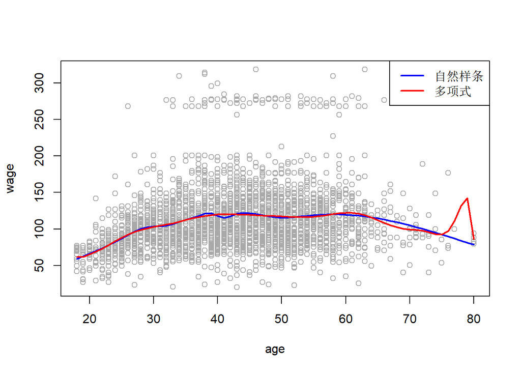

# 5 光滑样条

## 5.1 光滑样条简介

**假设我们样条函数为g(x),再求得该函数参数的同时，如何保证样条曲线的平滑性呢？**

光滑样条：将每个不同的$x_i$都设置为结点的自然三次样条

光滑样条拟合的目的：找到某个函数$g(x)$，使$RSS=\quad\sum_{i=1}^n{(y_i-g(x_i))^2}$尽量小，但同时控制其光滑程度，避免过拟合。

方法：最小化“损失函数+惩罚项”，即：
$$RSS(g(x_i),\lambda)=\sum_{i=1}^n{(y_i-g(x_i))^2} +\lambda\int {g''(t)^2dt},\lambda\geq0$$

通过矩阵形式转换成
$$RSS(\beta,\lambda)=(y-X\beta)^T(y-X\beta)+\lambda\beta^T\Omega_N\beta$$

其中，$\quad\sum_{i=1}^n{(y_i-g(x_i))^2}$是损失函数，使函数g能够更好地拟合数据；而函数$\lambda\int {g''(t)^2dt}$则对函数g的波动性进行惩罚。

然后用OLS的思想，对$\beta$求导为0，求出$\hat{\beta}$的值

$$\frac{\partial(\sum_{i=1}^n{(y_i-g(x_i))^2})}{\partial \beta_k}+\lambda g''(t)^2 \times 2g''(t) \times \frac{\partial g''(t)}{\partial \beta_k}=0$$

二阶导数$g''(t)$衡量的是函数g的**粗糙度**，如果函数在t处波动很大，则其绝对值很大。而常数λ则用来调节函数g曲线的粗糙程度，起到控制偏差-方差权衡的作用，λ越大，函数g越光滑。

- $\lambda=0$，惩罚项不起作用，函数g会快速波动，在各个训练集数据点上做插值
- $\lambda \to \infty$，g是最小二乘法求得的直线

$g(x)$具备的性质： 在结点$x_1,x_2,...,x_n$处是分段三次多项式，且一、二阶导数连续。 在边界节点之外的区域的线性的。 即$g(x)$自然三次样条，但是这种方式得到的自然三次样条有别于之的自然三次样条，可以认为是一种收缩版本。